# Using Multiple Linear Regression To Predict La-Liga Standings

Debaditya Chakraborty

2023-09-12

[figure not shown]

Jude Bellingham & Gavi

# Introduction

La Liga, Spain’s premier football league, is one of the most prestigious and competitive leagues in the world. Home to legendary clubs like Real Madrid, FC Barcelona, and Atlético Madrid, La Liga has produced some of the greatest players and most memorable moments in football history. The league is known for its blend of technical skill, tactical sophistication, and passionate fanbases, making it a focal point for football enthusiasts globally.

Each season, the battle for the top spots in La Liga is intense, with teams vying not only for the championship but also for qualifications to European competitions and to avoid relegation. Factors such as the experience of the manager, the financial health of the club, and the squad’s age and previous performances play significant roles in determining a team’s success. Understanding these elements is key to appreciating the dynamics that make La Liga one of the most exciting football competitions.

## What is MLR ?

MLR is a acronym for Multiple Linear Regression,Now to explain Multiple Linear Regression in layman terms, consider you have a chick farm(here by chicks i mean baby chickens sorry to disappoint ) and you want to predict the weight of chicks based on multiple `variables` , now what are these `variables` ? Well variables are different factors(I hope you’re not a statistician because this is used loosely here) which you think influence the weight of chicks, these could be the food given to the mother chicken, weight of mother chickens and other things. For keeping things simple we are assuming these to be numeric variables and not some categorical variable. Now we need some formula to connect the dots between these lets say `explanatory variables`(weight of mother chicken, food amount intake etc.) and the `dependent variable`(Weight of chicks) obviously i didn’t come up with the name since these are the usual terms used to explain the relationship , and the choice of these names is quite self explanatory unlike say something like regression(sorry mister galton) ,Here we call the first set of variables as `explanatory` since we assume they explain the variance(I hope you know what this is) in our`dependent` variable which by the way is a single variable. So this comes down to explaining $Y$ (Weight of chicks) using a set of variables $(X_1,X_2,\dots,X_n)$(Weight of mother chickens,Food intake of mother chickens etc.) , now what is the most simplest mathematical relationship that one can think of between two variables ? I hope you say *Linear* because that is indeed what we will assume here. We define the relation between the explanatory variable and the dependent variable using a linear function of the form $y=a+bx$, Generalizing this for multiple variables we get
$$Y=\alpha+\beta_1X1+\beta_2X_2+\dots+\beta_nX_n$$
, This is where we would’ve stopped if we were in the realm of mathematics, but since it is Statistics where our interest lies(Although some might say this is still the realm of Mathematics) so we introduce two new concepts one is a *Random Variable* and the other is *error*, The Mathematical theory behind Random Variables is much complicated to be explained here one can refer the Wikipedia Article or Read any Introductory Probability book, In simple words it is a variable which takes values from a set of numbers based on some probability (Sounds less like a variable more like a function right ?) . Now error is something that is out of our control, essentially part of our data that can’t be explained through the variables in our hand , If we had no randomness in our data and it was possible to explain the dependent variable through these explanatory variables using a deterministic function then there was no need to introduce error and Random Variables and so on but sadly the real world isn’t very simple so for real data there is always some error which is left un-accounted for. So with these our linear model becomes

$$Y=\alpha+\beta_1X1+\beta_2X_2+\dots+\beta_nX_n+\epsilon$$
Where $\epsilon$ is the error Random Random Variable $a$ is an additive constant and $\beta_i$’s are coefficients for the explanatory variables.There are much more complicated stuff inside this and this article is not a full explanation to this thing, Please read a book or an article dedicated to MLR to learn when to use , when not to use and when you *can’t* use this method of prediction.

Obviously this is a theoretical Model and for real data we would need some way to fit the data into this model, This is done using something called the *Least Squares Method*, Where the goal is to fit the data and find out the co-efficients associated with each variable by minimizing the value of sum of squares of $\epsilon$, which is minimizing the error sum of squares or simply minimizing the error for all the possible data points,we are taking squares to make sure the sum of these errors which include both positive and negative doesn’t become too close to zero .

And the fitted equation is given as-
$$y=a+b_1x_1+b_2x_2+\dots+b_nx_n+e$$
Based on this equation we predict outcomes from the available data. (Montgomery, Peck, and Vining 2013)

# Data Cleaning

We Start with loading the data from the excel file , the file can be accessed from [here](https://github.com/niceGriffith/La-liga-Prediction-Using-MLR/blob/main/Project_updated.xlsx).  
For this we use the packages `xlsx`(For .xlsx file handling),`dplyr` and`tidyverse` for data manipulation.

```r
library(xlsx)
library(dplyr)
library(tidyverse)

library(knitr)
library(kableExtra)
mk<-read.xlsx("Project_updated.xlsx",sheetIndex = 1)
#Clearing subcategory related empty rows,
mk<-mk[-1,]
# Assigning correct column names
colnames(mk)[4:6]<-c("Income","Expenditure","Gross")
#Removing some Columns which won't be used
mk<-mk[,-12:-10]
#Applying an algorithm to replace the team name rows
## with NA team names with correct team names
mk <- mk %>%
  # Create a group identifier based on the row number
  mutate(group = (row_number() - 1) %/% 5) %>%
  # Group by the new group identifier
  group_by(group) %>%
  # Fill the missing values in the team column with the first non-missing value in each group
  fill(Team, .direction = "down") %>%
  # Ungroup and remove the temporary group column
  ungroup() %>%
  select(-group)
#Making data numeric
mk <- mk %>% mutate(across(-2:-1,as.numeric))
#Removing empty rows
mk<-mk[-153:-136,]
#Removing NA's
fin_mk<-na.omit(mk)
head(fin_mk)%>%kbl()
```

| Team | Seasons | Average.Age.of.Players | Income | Expenditure | Gross | Manager.s.Years.of.experience | Previous.Standing | Points.Scored |
| --- | --- | --- | --- | --- | --- | --- | --- | --- |
| Real Madrid | 2018-19 | 27.30 | 1089 | 1318 | -229.2 | 7.5 | 3 | 68 |
| Real Madrid | 2019-20 | 22.50 | 1094 | 2844 | 1749.6 | 7.0 | 3 | 87 |
| Real Madrid | 2020-21 | 22.50 | 866 | 0 | 866.0 | 8.0 | 1 | 84 |
| Real Madrid | 2021-22 | 27.30 | 624 | 248 | 376.0 | 29.0 | 2 | 86 |
| Real Madrid | 2022-23 | 27.30 | 737 | 640 | 97.2 | 30.0 | 1 | 78 |
| FC Barcelona | 2018-19 | 26.04 | 1168 | 1129 | 39.6 | 21.0 | 1 | 87 |

So we have 9 variables out of which *Points Scored* is our dependent variable and the other six which are - “Average.Age.of.Players”,“Income”,“Expenditure” ,“Gross”, “Manager.s.Years.of.experience” & “Previous.Standing” are our *Explanatory Variables*.

# Visualization

Before modeliing we would like to check the relation between variables and the distribution of the dependent variable via some visualizations.

## Scatterplots

Here we plot some scatterplots between different variables in the dataset to get how they are related.

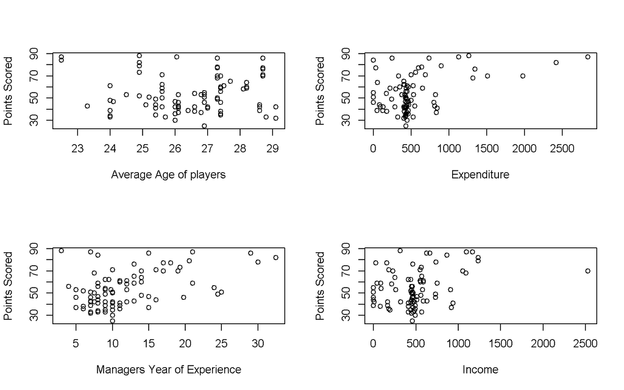

```r
par(mfrow=c(2,2))
plot(fin_mk$Average.Age.of.Players,fin_mk$Points.Scored,xlab = "Average Age of players",ylab="Points Scored")
plot(fin_mk$Expenditure,fin_mk$Points.Scored,xlab = "Expenditure",ylab="Points Scored")
plot(fin_mk$Manager.s.Years.of.experience,fin_mk$Points.Scored,xlab="Managers Year of Experience", ylab="Points Scored")
plot(fin_mk$Income,fin_mk$Points.Scored,xlab="Income", ylab="Points Scored")
```

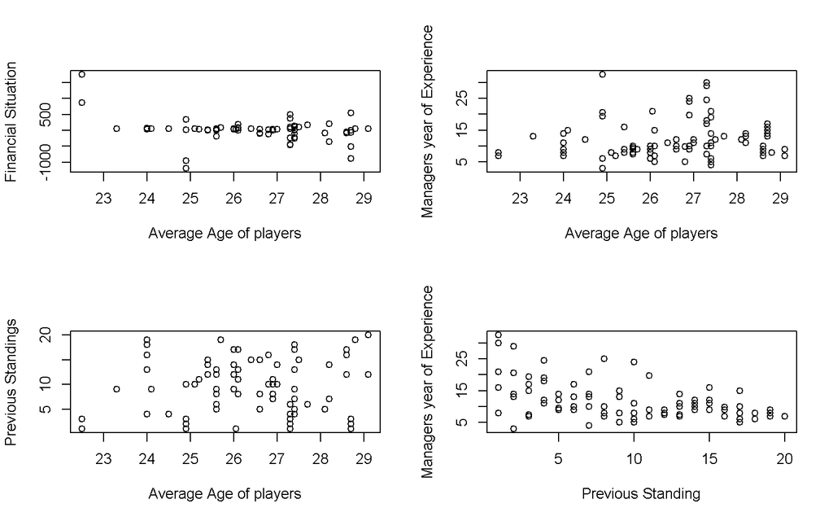

```r
plot(fin_mk$Average.Age.of.Players,fin_mk$Gross,xlab="Average Age of players",ylab="Financial Situation")
plot(fin_mk$Average.Age.of.Players,fin_mk$Manager.s.Years.of.experience,xlab="Average Age of players",ylab="Managers year of Experience")
plot(fin_mk$Average.Age.of.Players,fin_mk$Previous.Standing,xlab="Average Age of players",ylab="Previous Standings")
plot(fin_mk$Previous.Standing,fin_mk$Manager.s.Years.of.experience,xlab="Previous Standing",ylab="Managers year of Experience")
```

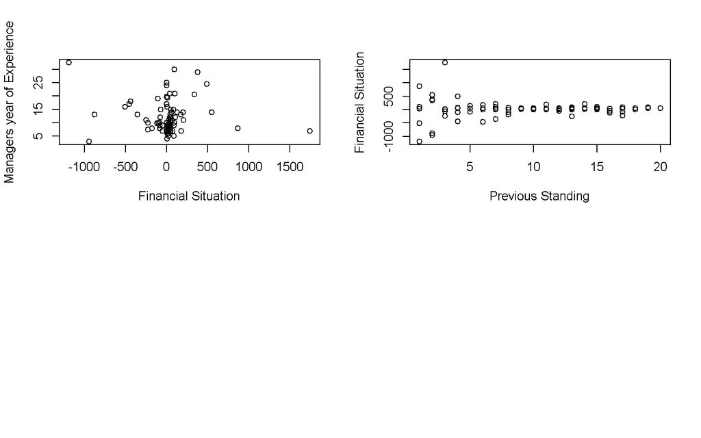

```r
plot(fin_mk$Gross,fin_mk$Manager.s.Years.of.experience,xlab="Financial Situation",ylab="Managers year of Experience")
plot(fin_mk$Previous.Standing,fin_mk$Gross,xlab="Previous Standing",ylab="Financial Situation")
```

## Histogram of Points Scored

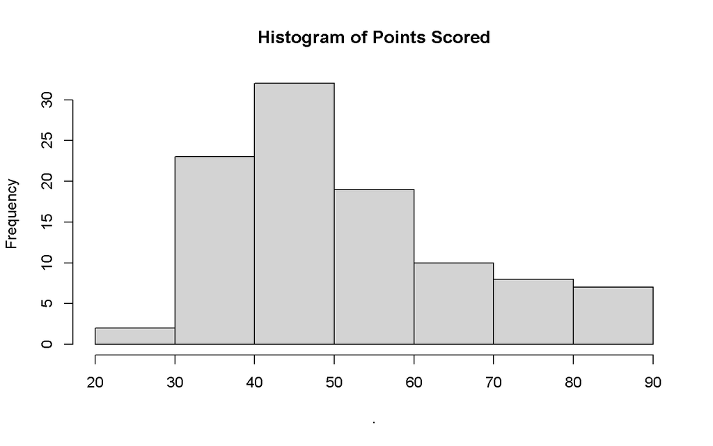

```r
mk$Points.Scored%>%hist(main="Histogram of Points Scored")
```

Here the histogram is slightly positively skewed, so to lower the skewness a log transformation may be used.

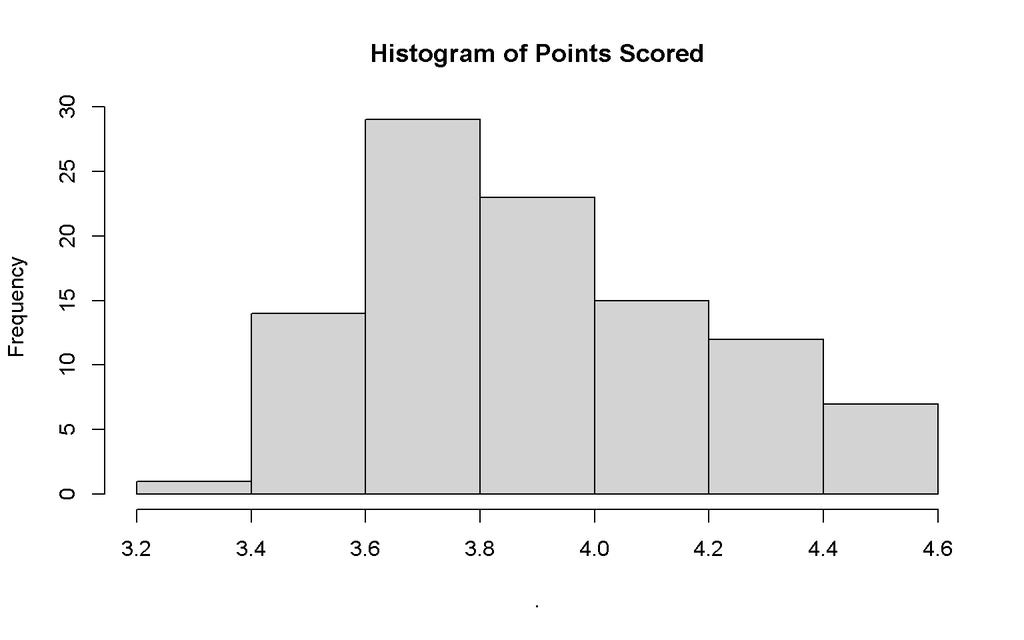

```r
log(mk$Points.Scored)%>%hist(main="Histogram of Points Scored")
```

Now the histogram looks much more symmetric and a linear model based on Normality Assumption is more likely to work.

## Correlation Matrix

We plot the correlation matrix using the `corrplot` packages corrplot function which is used to calculate the correlation matrix, and this is displayed via a visualization.

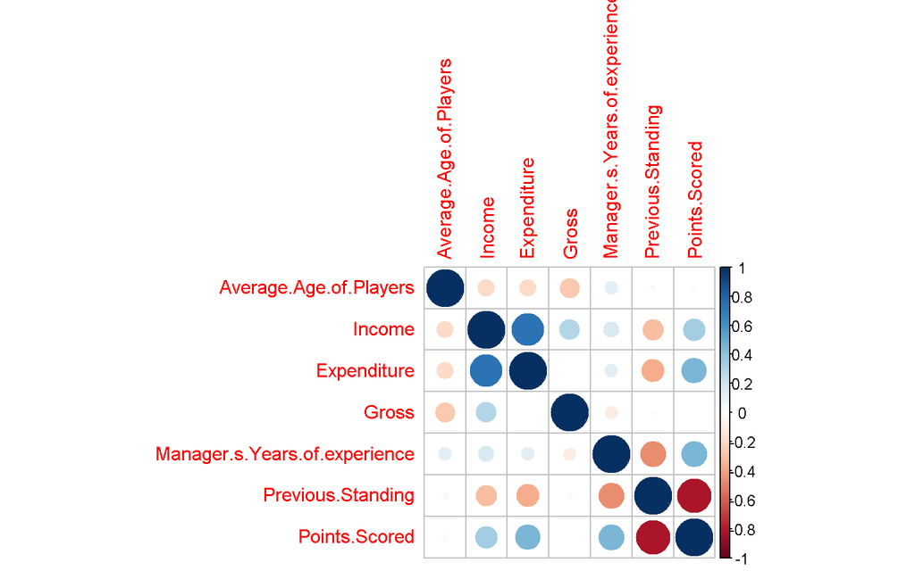

```r
mk_num<-fin_mk[,-2:-1]
cor_mat<-cor(mk_num)
corrplot::corrplot(cor_mat)
```

# Modeling

Finally we model the data using a multiple linear regression model, we use the explanatory variables Average age of players,Managers Year of Experience,Expenditure and Previous Standing. We have log transformed the Dependent variable so during prediction we apply the necessary inverse transformation which is the exponential transformation.

```r
model<-lm(log(Points.Scored)~Average.Age.of.Players+Manager.s.Years.of.experience+Expenditure+Previous.Standing,fin_mk)
kk<-round(exp(predict(model)),digits = 0)
df1<-data.frame(fin_mk$Team,kk)
colnames(df1)<-c("Team","Points")
x<-summary(model)
x
```

```
##
## Call:
## lm(formula = log(Points.Scored) ~ Average.Age.of.Players + Manager.s.Years.of.experience +
##     Expenditure + Previous.Standing, data = fin_mk)
##
## Residuals:
##      Min       1Q   Median       3Q      Max
## -0.79654 -0.08457 -0.01537  0.09832  0.38880
##
## Coefficients:
##                                 Estimate Std. Error t value Pr(>|t|)
## (Intercept)                    4.061e+00  3.404e-01  11.929  < 2e-16 ***
## Average.Age.of.Players         5.053e-03  1.261e-02   0.401   0.6897
## Manager.s.Years.of.experience  4.900e-03  3.594e-03   1.363   0.1765
## Expenditure                    8.914e-05  4.333e-05   2.057   0.0428 *
## Previous.Standing             -3.844e-02  4.140e-03  -9.285 1.95e-14 ***
## ---
## Signif. codes:  0 '***' 0.001 '**' 0.01 '*' 0.05 '.' 0.1 ' ' 1
##
## Residual standard error: 0.1727 on 82 degrees of freedom
## Multiple R-squared:  0.6706, Adjusted R-squared:  0.6545
## F-statistic: 41.73 on 4 and 82 DF,  p-value: < 2.2e-16
```

```r
y<-x$r.squared
```

We can see that the R^2 value(`y`) is particularly good ,and we have two statistically significant explanatory variables in the model. Although this is a very overly simplified model but as a basis this looks decent.

# Prediction

Here the prediction is based on the average of the given data, i was too lazy to look for a 23-24 data ;__;

If you want you can definitely collect the data and use this code to check how the model aligns with last years situation.

```r
team_means <- df1 %>%
  group_by(Team) %>%
  summarize(mean_value = round(mean(Points, na.rm = TRUE),digits = 0))
standings<-team_means%>%arrange(desc(mean_value))
colnames(standings)[2]<-"Predicted Points"

kable(standings,caption = "Predicted Standings")
```

Predicted Standings

| Team | Predicted Points |
| --- | --- |
| FC Barcelona | 76 |
| Real Madrid | 73 |
| Atletico Madrid | 72 |
| Sevilla FC | 65 |
| Valencia CF | 55 |
| Real Betis | 54 |
| Real Sociedad FC | 54 |
| Villareal CF | 54 |
| Athletic Club | 49 |
| CA Osasuna | 48 |
| Espaniyol FC | 48 |
| Getafe FC | 48 |
| Girona FC | 48 |
| FC Granada | 47 |
| Eibar fc | 46 |
| RC Celta | 45 |
| Levante FC | 42 |
| Leganes FC | 41 |
| Elche CF | 40 |
| Rayo Vallecano | 40 |
| Cadiz FC | 39 |
| Real Valliodad | 38 |
| Mallorca CF | 37 |
| Huesca FC | 34 |

Thank you for reading.

# References

Montgomery, D. C., E. A. Peck, and G. G. Vining. 2013. *Introduction to Linear Regression Analysis*. Wiley Series in Probability and Statistics. Wiley. https://books.google.co.in/books?id=lSyiRZh09oEC.